# Live Session 2: Getting data from unusual sources

Author

Zak Varty

## Data from the clipboard

Sometimes you need a fast, hacky way to read data into R. You can read data from the clipboard using the `{datapasta}` package. This is bad in terms of reproducibility but can sometimes be helpful to know about.

The package does well when reading from html and gives a reasonable starting point from pdf.

### Tasks

1. Use `{datapasta}` to load the table from `example-table.html` into R as a a tribble (row-wise specification of a tibble).

**Solution:**

```r
# Check the documentation
?datapasta::tribble_paste()
```

- Open html file, highlight and copy table
- When running `tribble_paste()` need to be sure cursor is somewhere sensible (new code block).
- The `L`’s here indicate that these are integer not double.

```r
datapasta::tribble_paste()
```

```r
example_tibble <- tibble::tribble(
~age,  ~gender, ~height,
 45L,   "Male",    161L,
 97L, "Female",    157L,
 39L, "Female",    150L,
 26L, "Female",    150L,
 22L,   "Male",    159L,
 55L, "Female",    147L,
 33L, "Female",    155L,
 21L,   "Male",    165L,
 87L,   "Male",    152L,
 96L,   "Male",    164L,
 95L,   "Male",    159L,
 31L, "Female",    150L,
 73L,   "Male",    168L,
 79L, "Female",    166L,
 21L,   "Male",    186L,
 21L, "Female",    152L,
 38L,   "Male",    186L,
 57L,       NA,    148L,
 73L,   "Male",    177L,
 84L, "Female",    185L,
 22L,   "Male",    170L,
 83L, "Female",    153L,
 64L,   "Male",    170L,
 57L,   "Male",    188L,
 65L,   "Male",    159L,
 20L, "Female",    174L,
 58L,       NA,    173L,
 89L, "Female",    163L,
 49L,   "Male",    170L,
 59L, "Female",    155L
)
```

2. Use `{datapasta}` to load the table of [Wimbledon Champions by Country](https://en.wikipedia.org/wiki/List_of_Wimbledon_gentlemen's_singles_champions#Championships_by_country) into R as a data frame. What goes wrong when you try to do the same for the [Women’s world record rowing times on water](https://en.wikipedia.org/wiki/List_of_world_best_times_in_rowing#On-water_records) and the [indoor rowing world record times](https://en.wikipedia.org/wiki/List_of_world_best_times_in_rowing#Indoor_records)?

**Solution:**

- `datapasta::df_paste()` works in a similar way
- The output is not quite so pretty because data frames are specified by column rather than by row.

```r
datapasta::df_paste()
```

```r
data.frame(
  stringsAsFactors = FALSE,
       check.names = FALSE,
           Country = c("Great Britain (GBR)[e][k]",
                       "United States (USA)","Australia (AUS)",
                       "Switzerland (SUI)","France (FRA)","Serbia (SRB)","Sweden (SWE)",
                       "Germany (GER)[l]","New Zealand (NZL)","Spain (ESP)",
                       "Croatia (CRO)","Czechoslovakia (TCH)[m]","Egypt (EGY)",
                       "Netherlands (NED)"),
       Amateur.Era = c(35L,18L,15L,0L,7L,0L,0L,
                       0L,4L,1L,0L,0L,1L,0L),
          Open.Era = c(2L, 15L, 6L, 8L, 0L, 7L, 7L, 4L, 0L, 3L, 1L, 1L, 0L, 1L),
        `All-time` = c(37L,33L,21L,8L,7L,7L,7L,
                       4L,4L,4L,1L,1L,1L,1L),
       First.title = c(1877L,1920L,1907L,2003L,
                       1924L,2011L,1976L,1985L,1910L,1966L,2001L,1973L,
                       1954L,1996L),
        Last.title = c(2016L,2000L,2002L,2017L,
                       1946L,2022L,1990L,1991L,1913L,2023L,2001L,1973L,
                       1954L,1996L)
)
```

```
                     Country Amateur.Era Open.Era All-time First.title
1  Great Britain (GBR)[e][k]          35        2       37        1877
2        United States (USA)          18       15       33        1920
3            Australia (AUS)          15        6       21        1907
4          Switzerland (SUI)           0        8        8        2003
5               France (FRA)           7        0        7        1924
6               Serbia (SRB)           0        7        7        2011
7               Sweden (SWE)           0        7        7        1976
8           Germany (GER)[l]           0        4        4        1985
9          New Zealand (NZL)           4        0        4        1910
10               Spain (ESP)           1        3        4        1966
11             Croatia (CRO)           0        1        1        2001
12   Czechoslovakia (TCH)[m]           0        1        1        1973
13               Egypt (EGY)           1        0        1        1954
14         Netherlands (NED)           0        1        1        1996
   Last.title
1        2016
2        2000
3        2002
4        2017
5        1946
6        2022
7        1990
8        1991
9        1913
10       2023
11       2001
12       1973
13       1954
14       1996
```

3. Use `{datapasta}` to load the standard normal distribution table into R. (note this will require some manual editing and does not work so well on Linux.)

**Solution:**

```r
datapasta::tribble_paste()
```

```r
tibble::tribble(
                         ~z..00..01..02..03..04..05..06..07..08..09,
  "0.0 .0000 .0040 .0080 .0120 .0160 .0199 .0239 .0279 .0319 .0359",
  "0.1 .0398 .0438 .0478 .0517 .0557 .0596 .0636 .0675 .0714 .0753",
  "0.2 .0793 .0832 .0871 .0910 .0948 .0987 .1026 .1064 .1103 .1141",
  "0.3 .1179 .1217 .1255 .1293 .1331 .1368 .1406 .1443 .1480 .1517",
  "0.4 .1554 .1591 .1628 .1664 .1700 .1736 .1772 .1808 .1844 .1879",
  "0.5 .1915 .1950 .1985 .2019 .2054 .2088 .2123 .2157 .2190 .2224",
  "0.6 .2257 .2291 .2324 .2357 .2389 .2422 .2454 .2486 .2517 .2549",
  "0.7 .2580 .2611 .2642 .2673 .2704 .2734 .2764 .2794 .2823 .2852",
  "0.8 .2881 .2910 .2939 .2967 .2995 .3023 .3051 .3078 .3106 .3133",
  "0.9 .3159 .3186 .3212 .3238 .3264 .3289 .3315 .3340 .3365 .3389",
  "1.0 .3413 .3438 .3461 .3485 .3508 .3531 .3554 .3577 .3599 .3621",
  "1.1 .3643 .3665 .3686 .3708 .3729 .3749 .3770 .3790 .3810 .3830",
  "1.2 .3849 .3869 .3888 .3907 .3925 .3944 .3962 .3980 .3997 .4015",
  "1.3 .4032 .4049 .4066 .4082 .4099 .4115 .4131 .4147 .4162 .4177",
  "1.4 .4192 .4207 .4222 .4236 .4251 .4265 .4279 .4292 .4306 .4319",
  "1.5 .4332 .4345 .4357 .4370 .4382 .4394 .4406 .4418 .4429 .4441",
  "1.6 .4452 .4463 .4474 .4484 .4495 .4505 .4515 .4525 .4535 .4545",
  "1.7 .4554 .4564 .4573 .4582 .4591 .4599 .4608 .4616 .4625 .4633",
  "1.8 .4641 .4649 .4656 .4664 .4671 .4678 .4686 .4693 .4699 .4706",
  "1.9 .4713 .4719 .4726 .4732 .4738 .4744 .4750 .4756 .4761 .4767",
  "2.0 .4772 .4778 .4783 .4788 .4793 .4798 .4803 .4808 .4812 .4817",
  "2.1 .4821 .4826 .4830 .4834 .4838 .4842 .4846 .4850 .4854 .4857",
  "2.2 .4861 .4864 .4868 .4871 .4875 .4878 .4881 .4884 .4887 .4890",
  "2.3 .4893 .4896 .4898 .4901 .4904 .4906 .4909 .4911 .4913 .4916",
  "2.4 .4918 .4920 .4922 .4925 .4927 .4929 .4931 .4932 .4934 .4936",
  "2.5 .4938 .4940 .4941 .4943 .4945 .4946 .4948 .4949 .4951 .4952",
  "2.6 .4953 .4955 .4956 .4957 .4959 .4960 .4961 .4962 .4963 .4964",
  "2.7 .4965 .4966 .4967 .4968 .4969 .4970 .4971 .4972 .4973 .4974",
  "2.8 .4974 .4975 .4976 .4977 .4977 .4978 .4979 .4979 .4980 .4981",
  "2.9 .4981 .4982 .4982 .4983 .4984 .4984 .4985 .4985 .4986 .4986",
  "3.0 .4987 .4987 .4987 .4988 .4988 .4989 .4989 .4989 .4990 .4990",
  "3.1 .4990 .4991 .4991 .4991 .4992 .4992 .4992 .4992 .4993 .4993",
  "3.2 .4993 .4993 .4994 .4994 .4994 .4994 .4994 .4995 .4995 .4995",
  "3.3 .4995 .4995 .4995 .4996 .4996 .4996 .4996 .4996 .4996 .4997",
  "3.4 .4997 .4997 .4997 .4997 .4997 .4997 .4997 .4997 .4997 .4998",
  "3.5 .4998 .4998 .4998 .4998 .4998 .4998 .4998 .4998 .4998 .4998"
  )
```

```
# A tibble: 36 × 1
   z..00..01..02..03..04..05..06..07..08..09
   <chr>
 1 0.0 .0000 .0040 .0080 .0120 .0160 .0199 .0239 .0279 .0319 .0359
 2 0.1 .0398 .0438 .0478 .0517 .0557 .0596 .0636 .0675 .0714 .0753
 3 0.2 .0793 .0832 .0871 .0910 .0948 .0987 .1026 .1064 .1103 .1141
 4 0.3 .1179 .1217 .1255 .1293 .1331 .1368 .1406 .1443 .1480 .1517
 5 0.4 .1554 .1591 .1628 .1664 .1700 .1736 .1772 .1808 .1844 .1879
 6 0.5 .1915 .1950 .1985 .2019 .2054 .2088 .2123 .2157 .2190 .2224
 7 0.6 .2257 .2291 .2324 .2357 .2389 .2422 .2454 .2486 .2517 .2549
 8 0.7 .2580 .2611 .2642 .2673 .2704 .2734 .2764 .2794 .2823 .2852
 9 0.8 .2881 .2910 .2939 .2967 .2995 .3023 .3051 .3078 .3106 .3133
10 0.9 .3159 .3186 .3212 .3238 .3264 .3289 .3315 .3340 .3365 .3389
# ℹ 26 more rows
```

The default output from Acrobat Reader interprets this as one character column named `z..00..01..02..03..04..05..06..07..08..09`. This can be easily fixed with a little bit of [multi-cursor magic](https://docs.posit.co/ide/user/ide/guide/productivity/text-editor.html#multiple-cursors).

```r
tibble::tribble(
  ~z , ~`0.01`,~`.002`, ~`.003`, ~`.004`, ~`.005`, ~`.006` ,~`.007`, ~`.008`, ~`.009`,
  0.0, 0.0000, 0.0040, 0.0080, 0.0120, 0.0160, 0.0199, 0.0239, 0.0279, 0.0319, 0.0359,
  0.1, 0.0398, 0.0438, 0.0478, 0.0517, 0.0557, 0.0596, 0.0636, 0.0675, 0.0714, 0.0753,
  0.2, 0.0793, 0.0832, 0.0871, 0.0910, 0.0948, 0.0987, 0.1026, 0.1064, 0.1103, 0.1141,
  0.3, 0.1179, 0.1217, 0.1255, 0.1293, 0.1331, 0.1368, 0.1406, 0.1443, 0.1480, 0.1517,
  0.4, 0.1554, 0.1591, 0.1628, 0.1664, 0.1700, 0.1736, 0.1772, 0.1808, 0.1844, 0.1879,
  0.5, 0.1915, 0.1950, 0.1985, 0.2019, 0.2054, 0.2088, 0.2123, 0.2157, 0.2190, 0.2224,
  0.6, 0.2257, 0.2291, 0.2324, 0.2357, 0.2389, 0.2422, 0.2454, 0.2486, 0.2517, 0.2549,
  0.7, 0.2580, 0.2611, 0.2642, 0.2673, 0.2704, 0.2734, 0.2764, 0.2794, 0.2823, 0.2852,
  0.8, 0.2881, 0.2910, 0.2939, 0.2967, 0.2995, 0.3023, 0.3051, 0.3078, 0.3106, 0.3133,
  0.9, 0.3159, 0.3186, 0.3212, 0.3238, 0.3264, 0.3289, 0.3315, 0.3340, 0.3365, 0.3389,
  1.0, 0.3413, 0.3438, 0.3461, 0.3485, 0.3508, 0.3531, 0.3554, 0.3577, 0.3599, 0.3621,
  1.1, 0.3643, 0.3665, 0.3686, 0.3708, 0.3729, 0.3749, 0.3770, 0.3790, 0.3810, 0.3830,
  1.2, 0.3849, 0.3869, 0.3888, 0.3907, 0.3925, 0.3944, 0.3962, 0.3980, 0.3997, 0.4015,
  1.3, 0.4032, 0.4049, 0.4066, 0.4082, 0.4099, 0.4115, 0.4131, 0.4147, 0.4162, 0.4177,
  1.4, 0.4192, 0.4207, 0.4222, 0.4236, 0.4251, 0.4265, 0.4279, 0.4292, 0.4306, 0.4319,
  1.5, 0.4332, 0.4345, 0.4357, 0.4370, 0.4382, 0.4394, 0.4406, 0.4418, 0.4429, 0.4441,
  1.6, 0.4452, 0.4463, 0.4474, 0.4484, 0.4495, 0.4505, 0.4515, 0.4525, 0.4535, 0.4545,
  1.7, 0.4554, 0.4564, 0.4573, 0.4582, 0.4591, 0.4599, 0.4608, 0.4616, 0.4625, 0.4633,
  1.8, 0.4641, 0.4649, 0.4656, 0.4664, 0.4671, 0.4678, 0.4686, 0.4693, 0.4699, 0.4706,
  1.9, 0.4713, 0.4719, 0.4726, 0.4732, 0.4738, 0.4744, 0.4750, 0.4756, 0.4761, 0.4767,
  2.0, 0.4772, 0.4778, 0.4783, 0.4788, 0.4793, 0.4798, 0.4803, 0.4808, 0.4812, 0.4817,
  2.1, 0.4821, 0.4826, 0.4830, 0.4834, 0.4838, 0.4842, 0.4846, 0.4850, 0.4854, 0.4857,
  2.2, 0.4861, 0.4864, 0.4868, 0.4871, 0.4875, 0.4878, 0.4881, 0.4884, 0.4887, 0.4890,
  2.3, 0.4893, 0.4896, 0.4898, 0.4901, 0.4904, 0.4906, 0.4909, 0.4911, 0.4913, 0.4916,
  2.4, 0.4918, 0.4920, 0.4922, 0.4925, 0.4927, 0.4929, 0.4931, 0.4932, 0.4934, 0.4936,
  2.5, 0.4938, 0.4940, 0.4941, 0.4943, 0.4945, 0.4946, 0.4948, 0.4949, 0.4951, 0.4952,
  2.6, 0.4953, 0.4955, 0.4956, 0.4957, 0.4959, 0.4960, 0.4961, 0.4962, 0.4963, 0.4964,
  2.7, 0.4965, 0.4966, 0.4967, 0.4968, 0.4969, 0.4970, 0.4971, 0.4972, 0.4973, 0.4974,
  2.8, 0.4974, 0.4975, 0.4976, 0.4977, 0.4977, 0.4978, 0.4979, 0.4979, 0.4980, 0.4981,
  2.9, 0.4981, 0.4982, 0.4982, 0.4983, 0.4984, 0.4984, 0.4985, 0.4985, 0.4986, 0.4986,
  3.0, 0.4987, 0.4987, 0.4987, 0.4988, 0.4988, 0.4989, 0.4989, 0.4989, 0.4990, 0.4990,
  3.1, 0.4990, 0.4991, 0.4991, 0.4991, 0.4992, 0.4992, 0.4992, 0.4992, 0.4993, 0.4993,
  3.2, 0.4993, 0.4993, 0.4994, 0.4994, 0.4994, 0.4994, 0.4994, 0.4995, 0.4995, 0.4995,
  3.3, 0.4995, 0.4995, 0.4995, 0.4996, 0.4996, 0.4996, 0.4996, 0.4996, 0.4996, 0.4997,
  3.4, 0.4997, 0.4997, 0.4997, 0.4997, 0.4997, 0.4997, 0.4997, 0.4997, 0.4997, 0.4998,
  3.5, 0.4998, 0.4998, 0.4998, 0.4998, 0.4998, 0.4998, 0.4998, 0.4998, 0.4998, 0.4998
  )
```

## API Example - googlesheets4

You might find yourself in a situation where your data are stored in the cloud, for example in google sheets. In one sense this is good: the data are not lost if your laptop breaks and any changes or updates to the data are tracked.

On the other hand, you have to manually download your data each time you want to update your analysis. APIs can come to our rescue here - in particular the `{googlesheets4`} package, which acts as a wrapper for [version 4 of the sheets API](https://developers.google.com/sheets).

You can install the package from CRAN

```r
install.packages("googlesheets4")
```

We can then read the gapminder dataset as follows.

```r
gapminder_url <- "https://docs.google.com/spreadsheets/d/1U6Cf_qEOhiR9AZqTqS3mbMF3zt2db48ZP5v3rkrAEJY/edit#gid=780868077"
googlesheets4::read_sheet(gapminder_url)
```

```
✔ Reading from "gapminder".
```

```
✔ Range 'Africa'.
```

```
# A tibble: 624 × 6
   country continent  year lifeExp      pop gdpPercap
   <chr>   <chr>     <dbl>   <dbl>    <dbl>     <dbl>
 1 Algeria Africa     1952    43.1  9279525     2449.
 2 Algeria Africa     1957    45.7 10270856     3014.
 3 Algeria Africa     1962    48.3 11000948     2551.
 4 Algeria Africa     1967    51.4 12760499     3247.
 5 Algeria Africa     1972    54.5 14760787     4183.
 6 Algeria Africa     1977    58.0 17152804     4910.
 7 Algeria Africa     1982    61.4 20033753     5745.
 8 Algeria Africa     1987    65.8 23254956     5681.
 9 Algeria Africa     1992    67.7 26298373     5023.
10 Algeria Africa     1997    69.2 29072015     4797.
# ℹ 614 more rows
```

**Note:** If you try and run this code, you’ll likely have a browser tab asking you to sign in with Google and give permissions. Signing in and granting those permissions will mean that `{googlesheets4`} is be able to do the same things you can with Sheets in the browser (create, read, edit, download, delete). **You do not need to do that for this tutorial**.

[figure not shown]

[figure not shown]

If you only want to read public Sheets (as we do in this example), then you can put googlesheets4 into a de-authorized state.

```r
googlesheets4::gs4_deauth()
```

This will send an API key that can be used to access public resources for which no Google sign-in is required.

### Tasks

1. Use `{googlesheets4`} to load a copy of our earlier example data set into R from the address provided.

`https://docs.google.com/spreadsheets/d/1Xk7HX-EihNMCRaG1bsltAgkZKds_pz1tKIcw7pYEmEU/edit?usp=sharing`

```r
example_data_url <- "https://docs.google.com/spreadsheets/d/1Xk7HX-EihNMCRaG1bsltAgkZKds_pz1tKIcw7pYEmEU/edit?usp=sharing"
googlesheets4::read_sheet(example_data_url)
```

```
✔ Reading from "example-table".
```

```
✔ Range 'plain text version'.
```

```
# A tibble: 30 × 3
     age gender height
   <dbl> <chr>   <dbl>
 1    45 Male      161
 2    97 Female    157
 3    39 Female    150
 4    26 Female    150
 5    22 Male      159
 6    55 Female    147
 7    33 Female    155
 8    21 Male      165
 9    87 Male      152
10    96 Male      164
# ℹ 20 more rows
```

2. Adapt your previous answer to read only the first 5 rows.

```r
googlesheets4::read_sheet(example_data_url, n_max = 5)
```

```
✔ Reading from "example-table".
```

```
✔ Range 'plain text version'.
```

```
# A tibble: 5 × 3
    age gender height
  <dbl> <chr>   <dbl>
1    45 Male      161
2    97 Female    157
3    39 Female    150
4    26 Female    150
5    22 Male      159
```

3. Adapt your previous answer to read only the first 3 rows of the age and height columns.

We can use the `range` argument to have more detailed control over which rows and columns are read from the spreadsheet, but this only works for contiguous regions. We therefore read the two columns separately and joint these together into a single tibble.

```r
ages <- googlesheets4::read_sheet(example_data_url, range = "A1:A4")
```

```
✔ Reading from "example-table".
```

```
✔ Range 'A1:A4'.
```

```r
heights <- googlesheets4::read_sheet(example_data_url, range = "C1:C4")
```

```
✔ Reading from "example-table".
```

```
✔ Range 'C1:C4'.
```

```r
cbind(ages,heights)
```

```
  age height
1  45    161
2  97    157
3  39    150
```

4. Read the second sheet, which has cell formatting. Has this caused any problems? How can you specify which sheet (tab) you want to read?

```r
googlesheets4::read_sheet(example_data_url, sheet = 2)
```

```
✔ Reading from "example-table".
```

```
✔ Range ''with formatting''.
```

```
# A tibble: 30 × 3
     age gender height
   <dbl> <chr>   <dbl>
 1    45 Male      161
 2    97 Female    157
 3    39 Female    150
 4    26 Female    150
 5    22 Male      159
 6    55 Female    147
 7    33 Female    155
 8    21 Male      165
 9    87 Male      152
10    96 Male      164
# ℹ 20 more rows
```

No problems (but the formatting does get ignored, which might be problematic if this formatting was meaningful).

5. Read the indoor rowing records from the third sheet into R.

```r
rowing_header <- googlesheets4::read_sheet(example_data_url, range = "Sheet3!B1:H1")
```

```
✔ Reading from "example-table".
```

```
✔ Range ''Sheet3'!B1:H1'.
```

```r
sheets_rowing <- googlesheets4::read_sheet(example_data_url, range = "Sheet3!B3:H14", col_names = colnames(rowing_header) )
```

```
✔ Reading from "example-table".
```

```
✔ Range ''Sheet3'!B3:H14'.
```

```r
sheets_rowing
```

```
# A tibble: 12 × 7
   Type  Category          Time   Split  Nation                       Year Name
   <chr> <chr>             <chr>  <chr>  <chr>                       <dbl> <chr>
 1 SIR   Open Men          5:35.8 1:23.9 Australia Australia          2018 Josh…
 2 SIR   Lightweight Men   5:56.7 1:29.2 Denmark Denmark              2012 Henr…
 3 SIR   Open Women        6:21.1 1:35.3 United States United States  2021 Broo…
 4 SIR   Lightweight Women 6:53.8 1:43.4 Canada Canada                2019 Jenn…
 5 IRwS  Open Men          5:59.9 NA     Australia Australia          2010 Nick…
 6 IRwS  Lightweight Men   6:10.3 NA     Italy Italia                 2017 Andr…
 7 IRwS  Open Women        6:46.8 NA     United States United States  2006 Tali…
 8 IRwS  Lightweight Women 7:29.7 NA     United States United States  2008 Lynn…
 9 DIR   Open Men          5:41.8 NA     New Zealand New Zealand      2012 Eric…
10 DIR   Lightweight Men   6:15.6 NA     United Kingdom Great Brita…  2017 Tom …
11 DIR   Open Women        8:00.6 NA     United States United States  2015 Kare…
12 DIR   Lightweight Women 8:10.4 NA     United States United States  2013 Eliz…
```

- For examples of how to read private documents or write to Google sheets files see the documentation.
- If you would like to use R to manage your Google drive files more generally, then check out the [googledrive](https://googledrive.tidyverse.org/) package.

## API Example 2 - Google Trends

Go to Google Trends and recreate this time series plot of the search popularity of social media platforms over the last 12 months.

[figure not shown]

### Tasks

Use the {gtrendsR} package to reproducibly recreate this plot.

(**Note:** fast internet connections can mess this up and cause an error because the request rate is too high. Setting `onlyInterest=TRUE` is a way to reduce this issue by making fewer queries to the API. Don’t worry if it still throws an error - it just means your computer/internet are too good for the API!)

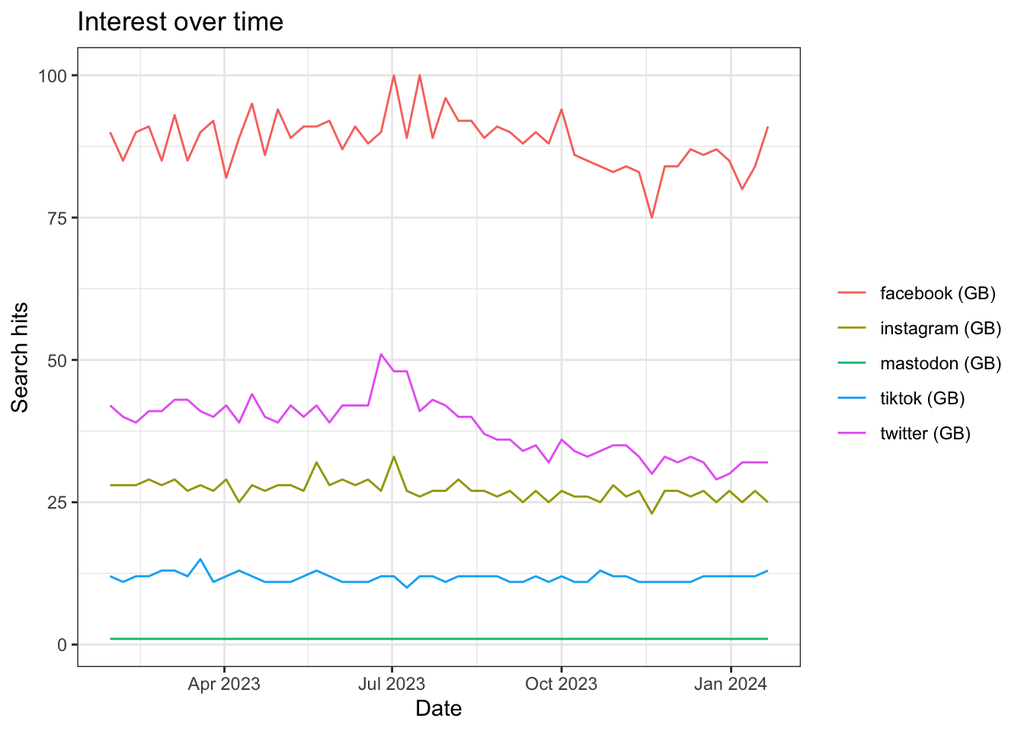

```r
library(gtrendsR)
gt <- gtrendsR::gtrends(
  keyword = c("facebook","twitter", "instagram", "tiktok", "mastodon"),
  geo = "GB",
  time = "today 12-m",
  onlyInterest = TRUE)
plot(gt)
```